# Download and work with NEON Aquatic Instrument Data

## Introduction Links

Getting started with NEON data: https://www.neonscience.org/resources/getting-started-neon-data-resources

Contact us form: https://www.neonscience.org/about/contact-us

Teaching Modules: https://www.neonscience.org/resources/learning-hub/teaching-modules  
QUBES modules: https://qubeshub.org/community/groups/neon/educational_resources  
EDDIE modules : https://serc.carleton.edu/eddie/macrosystems/index.html

Spatial data and maps: https://neon.maps.arcgis.com/home/index.html

NEON data portal: https://data.neonscience.org/

NEONScience GitHub repo: https://github.com/NEONScience  
ASLO 2025 AIS Workshop GitHub repo: https://github.com/NEONScience/WORKSHOP-ASLO-2025

## Tutorial

This tutorial covers downloading NEON Aquatic Instrument System (AIS) data using the neonUtilities R package, as well as basic instruction in beginning to explore and work with the downloaded data. This includes navigating data documentation, separating data using the horizontal location (HOR) variable, interpreting quality flags, and combining multiple data sets.

## Download Files and Load Directly to R: loadByProduct()

The most popular function in `neonUtilities` is `loadByProduct()`. This function downloads data from the NEON API, merges the site-by-month files, and loads the resulting data tables into the R environment, assigning each data type to the appropriate R class. This is a popular choice because it ensures you’re always working with the most up-to-date data, and it ends with ready-to-use tables in R. However, if you use it in a workflow you run repeatedly, keep in mind it will re-download the data every time.

Before we get the NEON data, we need to install (if not already done) and load the neonUtilities R package, as well as other packages we will use in the analysis.

```r
# # Install neonUtilities package if you have not yet.
# install.packages("neonUtilities")
# install.packages("ggplot2")
# install.packages("lubridate")
# install.packages("plyr")
```

```r
# Set global option to NOT convert all character variables to factors
options(stringsAsFactors=F)

# Load required packages
library(neonUtilities)
library(ggplot2)
library(lubridate)
library(plyr)
```

The inputs to `loadByProduct()` control which data to download and how to manage the processing. The following are frequently used inputs:

- `dpID`: the data product ID, e.g. DP1.20288.001
- `site`: defaults to “all”, meaning all sites with available data; can be a vector of 4-letter NEON site codes, e.g. `c("MART","ARIK","BARC")`.
- `startdate` and `enddate`: defaults to NA, meaning all dates with available data; or a date in the form YYYY-MM, e.g. 2017-06. Since NEON data are provided in month packages, finer scale querying is not available. Both start and end date are inclusive.
- `package`: either basic or expanded data package. Expanded data packages generally include additional information about data quality, such as individual quality flag test results. Not every NEON data product has an expanded package; if the expanded package is requested but there isn’t one, the basic package will be downloaded.
- `release`: The data release to be downloaded; either ‘current’ or the name of a release, e.g. ‘RELEASE-2021’. ‘current’ returns provisional data in addition to the most recent release. To download only provisional data, use release=‘PROVISIONAL’. Defaults to ‘current’. See https://www.neonscience.org/data-samples/data-management/data-revisions-releases for more information
- `avg`: defaults to “all”, to download all data; or the number of minutes in the averaging interval. See example below; only applicable to IS data.
- `check.size`: T or F; should the function pause before downloading data and warn you about the size of your download? Defaults to T; if you are using this function within a script or batch process you will want to set this to F.
- `token`: this allows you to input your NEON API token to obtain faster downloads. Learn more about NEON API tokens in the **Using an API Token when Accessing NEON Data with neonUtilities** tutorial.

There are additional inputs you can learn about in the **Use the neonUtilities R Package to Access NEON Data** tutorial.

The `dpID` is the data product identifier of the data you want to download. The DPID can be found on the [Explore Data Products page](http://data.neonscience.org/data-products/explore).

It will be in the form DP#.#####.###. For this tutorial, we’ll use some data products collected in NEON’s Aquatic Instrument System:

- DP1.20288.001: Water quality
- DP1.20033.001: Nitrate in surface water
- DP4.00130.001: Continuous discharge

Now it’s time to consider the NEON field site of interest. If not specified, the default will download a data product from all sites. The following are 4-letter site codes for NEON’s 34 aquatics sites as of 2022:

ARIK = Arikaree River CO  
BARC = Barco Lake FL  
BIGC = Upper Big Creek CA  
BLDE = Black Deer Creek WY  
BLUE = Blue River OK  
BLWA = Black Warrior River AL CARI = Caribou Creek AK  
COMO = Como Creek CO  
CRAM = Crampton Lake WI  
CUPE = Rio Cupeyes PR  
FLNT = Flint River GA  
GUIL = Rio Guilarte PR HOPB = Lower Hop Brook MA  
KING = Kings Creek KS  
LECO = LeConte Creek TN  
LEWI = Lewis Run VA  
LIRO = Little Rock Lake WI  
MART = Martha Creek WA MAYF = Mayfield Creek AL  
MCDI = McDiffett Creek KS  
MCRA = McRae Creek OR  
OKSR = Oksrukuyik Creek AK  
POSE = Posey Creek VA  
PRIN = Pringle Creek TX  
PRLA = Prairie Lake ND  
PRPO = Prairie Pothole ND  
REDB = Red Butte Creek UT  
SUGG = Suggs Lake FL  
SYCA = Sycamore Creek AZ  
TECR = Teakettle Creek CA  
TOMB = Lower Tombigbee River AL  
TOOK = Toolik Lake AK  
WALK = Walker Branch TN  
WLOU = West St Louis Creek CO

In this exercise, we will pull data from only one NEON field site, Walker Branch TN (WALK) from July, 2019. Quick link to the WALK site page: https://www.neonscience.org/field-sites/walk. Just substitute the 4-letter site code for any other site at the end of the url.

Now let us download our data. If you are not using a NEON token to download your data, neonUtilities will ignore the `token` input. We set `check.size = F`  
so that the script runs well but remember you always want to check your download size first.

```r
# download data of interest - Water Quality
waq <- neonUtilities::loadByProduct(dpID="DP1.20288.001",
                     site="WALK",
                     startdate="2019-07",
                     enddate="2019-07",
                     package="expanded",
                     release= "current",
                     token = Sys.getenv("NEON_TOKEN"),
                     check.size = F)
```

## Files Associated with Downloads

The data we’ve downloaded comes as an object that is a named list of objects. To work with each of them, select them from the list using the `$` operator.

```r
# view all components of the list
names(waq)
```

```
##  [1] "ais_maintenance"             "ais_multisondeCleanCal"
##  [3] "categoricalCodes_20288"      "citation_20288_RELEASE-2025"
##  [5] "issueLog_20288"              "readme_20288"
##  [7] "science_review_flags_20288"  "sensor_positions_20288"
##  [9] "variables_20288"             "waq_instantaneous"
```

```r
# View the dataFrame
View(waq$waq_instantaneous)
```

### Saving out a file to work with in another program

```r
# Save out a csv
utils::write.csv(waq$waq_instantaneous,
                 "~/GitHub/WORKSHOP-ASLO-2025/waq_instantaneous.csv",
                 row.names = FALSE)
```

### Challenge: Download Other Related Data products

Using what you’ve learned above, can you modify the code to download data for the following parameters?

- DP1.20033.001: Nitrate in surface water
- DP4.00130.001: Continuous discharge
- The expanded data tables
- Dates matching the other data products you’ve downloaded

```r
# download data of interest - Nitrate in Surface Water
nsw <-  loadByProduct(dpID="DP1.20033.001", site="WALK",
                      startdate="2019-07", enddate="2019-07",
                      package="expanded",
                      token = Sys.getenv("NEON_TOKEN"),
                      check.size = F)

csd <- loadByProduct(dpID="DP4.00130.001", site="WALK",
                     startdate="2019-07", enddate="2019-07",
                     package="expanded",
                     token = Sys.getenv("NEON_TOKEN"),
                     check.size = F)

# Also for pulling geomorphology survey
geo <- loadByProduct(dpID="DP4.00131.001", site="WALK",
                     package="expanded",
                     token = Sys.getenv("NEON_TOKEN"),
                     check.size = F)
geoResults <- geo$geo_resultsFile
geoResults$dataFilePath
# Paste url into a browser and the zip file with shapefiles and kmz and pdf will download

# # Or if you're getting a bunch you could also use neonUtilities function (uncomment to use) to access geomorphology data
# geoFolder <- zipsByProduct(dpID="DP4.00131.001")
```

If you’d like you can use the `$` operator to assign an object from an item in the list. If you prefer to extract each table from the list and work with it as independent objects, which we will do, you can use the `list2env()` function.

```r
# unlist the variables and add to the global environment
list2env(waq, .GlobalEnv)
```

```
## <environment: R_GlobalEnv>
```

- **data file(s)**: There will always be one or more dataframes that include the primary data of the data product you downloaded. Multiple dataframes are available when there are related datatables for a single data product.
- **readme_xxxxx**: The readme file, with the corresponding 5 digits from the data product number, provides you with important information relevant to the data product and the specific instance of downloading the data. Here you can find manual flagging notes for all sites, locations, and time periods.
- **sensor_postions_xxxxx**: this file contains information about the coordinates of each sensor, relative to a reference location.
- **variables_xxxxx**: this file contains all the variables found in the associated data table(s). This includes full definitions, units, and other important information.

```r
list2env(nsw, .GlobalEnv)
```

```
## <environment: R_GlobalEnv>
```

```r
list2env(csd, .GlobalEnv)
```

```
## <environment: R_GlobalEnv>
```

```r
# Just a little snippet if anyone wants to convert to local time
# NEON data downloads are all in UTC timezone, unless otherwise specified
devtools::install_github(repo = "NEONScience/NEON-geolocation",
                         subdir = "geoNEON")
```

```
## Using github PAT from envvar GITHUB_PAT. Use `gitcreds::gitcreds_set()` and unset GITHUB_PAT in .Renviron (or elsewhere) if you want to use the more secure git credential store instead.
```

```
## Skipping install of 'geoNEON' from a github remote, the SHA1 (59bdef7f) has not changed since last install.
##   Use `force = TRUE` to force installation
```

```r
siteLocInfo <- geoNEON::getLocBySite("WALK",
                                     type = "site",
                                     history = F,
                                     token = NA_character_)

localTZ <- siteLocInfo$siteTimezone

waq_instantaneous$localStartTime <- format(waq_instantaneous$startDateTime,"%Y-%m-%dT%H:%M",tz = localTZ)
```

Note that a few more objects were added to the Global Environment, including:

- `NSW_15_minute`
- `csd_continuousDischarge`

The `15_minute` name indicates the time-averaging intervals in a dataset. Other examples may include `5_min` and `30_min` in the same data product, such as elevation of surface water (DP1.20016.001). If only one time average interests you, you may specify the time interval of interest when downloading the data when calling `neonUtilities::loadByProduct()`.

## Data from Different Sensor Locations (HOR)

NEON often collects the same type of data from sensors in different locations. These data are delivered together but you will frequently want to plot the data separately or only include data from one sensor in your analysis. NEON uses the `horizontalPosition` variable in the data tables to describe which sensor data is collected from. The `horizontalPosition` is always a three digit number for AIS data. Non-shoreline HOR examples as of 2020 at AIS sites include:

- 101: stream sensors located at the **upstream** station on a **monopod mount**,
- 111: stream sensors located at the **upstream** station on an **overhead cable mount**,
- 131: stream sensors located at the **upstream** station on a **stand alone pressure transducer mount**,
- 102: stream sensors located at the **downstream** station on a monopod mount,
- 112: stream sensors located at the **downstream** station on an **overhead cable mount**
- 132: stream sensors located at the **downstream** station on a **stand alone pressure transducer mount**,
- 110: **pressure transducers** mounted to a **staff gauge**.
- 103: sensors mounted on **buoys in lakes or rivers**
- 130 and 140: sensors mounted in the **littoral zone** of lakes

You’ll frequently want to know which sensor locations are represented in your data. We can do this by looking for the `unique()` position designations in `horizontalPostions`.

```r
# which sensor locations exist for water quality, DP1.20288.001?
cat("Water quality horizontal positions: ", unique(waq_instantaneous$horizontalPosition))
```

```
## Water quality horizontal positions:  101 102
```

We can see that there are two water quality sensor positions at WALK in July 2019. As the locations of sensors can change at sites over time (especially with aquatic sensors as AIS sites undergo redesigns) it is a good idea to check horizontal positions when you’re adding in new locations or a new date range to your analyses.

Let’s check the HOR locations for surface water nitrate and continuous discharge too:

```r
# which sensor locations exist for other data products?
print("Nitrate in Surface Water horizontal positions: ")
```

```
## [1] "Nitrate in Surface Water horizontal positions: "
```

```r
unique(NSW_15_minute$horizontalPosition)
```

```
## [1] "102"
```

```r
print("Continuous Discharge horizontal positions: ")
```

```
## [1] "Continuous Discharge horizontal positions: "
```

```r
unique(csd_continuousDischarge$stationHorizontalID)
```

```
## [1] "102"
```

Now we can use this information to split water quality data into the two different sensor set locations: upstream and the downstream.

```r
# Split data into separate dataframes by upstream/downstream locations.

waq_up <-
  waq_instantaneous[(waq_instantaneous$horizontalPosition=="101"),]
waq_down <-
  waq_instantaneous[(waq_instantaneous$horizontalPosition=="102"),]
```

## Plot Data

First, let’s identify the column names important for plotting - time and dissolved oxygen data:

```r
# One option is to view column names in the data frame
colnames(waq_instantaneous)
```

```
##   [1] "domainID"                      "siteID"
##   [3] "horizontalPosition"            "verticalPosition"
##   [5] "startDateTime"                 "endDateTime"
##   [7] "sensorDepth"                   "sensorDepthExpUncert"
##   [9] "sensorDepthRangeQF"            "sensorDepthNullQF"
##  [11] "sensorDepthGapQF"              "sensorDepthValidCalQF"
##  [13] "sensorDepthSuspectCalQF"       "sensorDepthPersistQF"
##  [15] "sensorDepthAlphaQF"            "sensorDepthBetaQF"
##  [17] "sensorDepthFinalQF"            "sensorDepthFinalQFSciRvw"
##  [19] "specificConductance"           "specificConductanceExpUncert"
##  [21] "specificConductanceRangeQF"    "specificConductanceStepQF"
##  [23] "specificConductanceNullQF"     "specificConductanceGapQF"
##  [25] "specificConductanceSpikeQF"    "specificConductanceValidCalQF"
##  [27] "specificCondSuspectCalQF"      "specificConductancePersistQF"
##  [29] "specificConductanceAlphaQF"    "specificConductanceBetaQF"
```

[output cut: 61 more lines]

```r
# Alternatively, view the variables object corresponding to the data product for more information
View(variables_20288)
```

Quite a few columns in the water quality data product!

The time column we’ll consider for instrumented systems is `endDateTime` because it approximately represents data within the interval on or before the `endDateTime` time stamp. Timestamp column choice matters for time-aggregated datasets, but should not matter for instantaneous data such as water quality.

When interpreting data, keep in mind NEON timestamps are always in UTC.

The data column we would like to plot is labeled `dissolvedOxygen`.

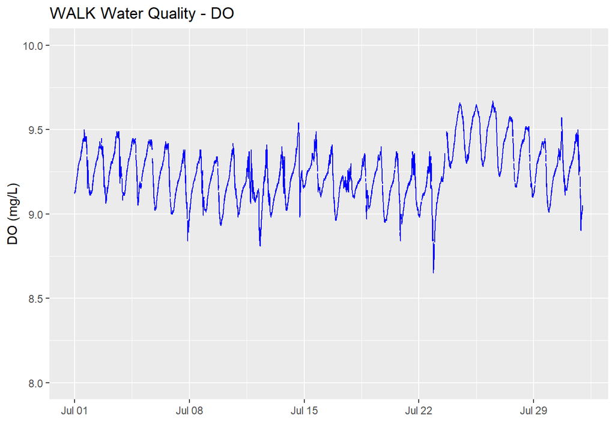

```r
# plot
plot_DO <- ggplot(data =waq_down,
                   aes(endDateTime, dissolvedOxygen)) +
                   geom_line(na.rm=TRUE, color="blue") +
                    ylim(8, 10) + ylab("DO (mg/L)") + xlab(" ") +
                   ggtitle("WALK Water Quality - DO")

plot_DO
```

Now let’s try plotting fDOM. fDOM is only measured at the downstream location and is found in the same dataframe (‘waq_down’). The column we would like to plot is labeled ‘fDOM’. (Note there is also a column labeled rawCalibratedfDOM. This is raw data from the YSI multisonde which has not been absorbance corrected).

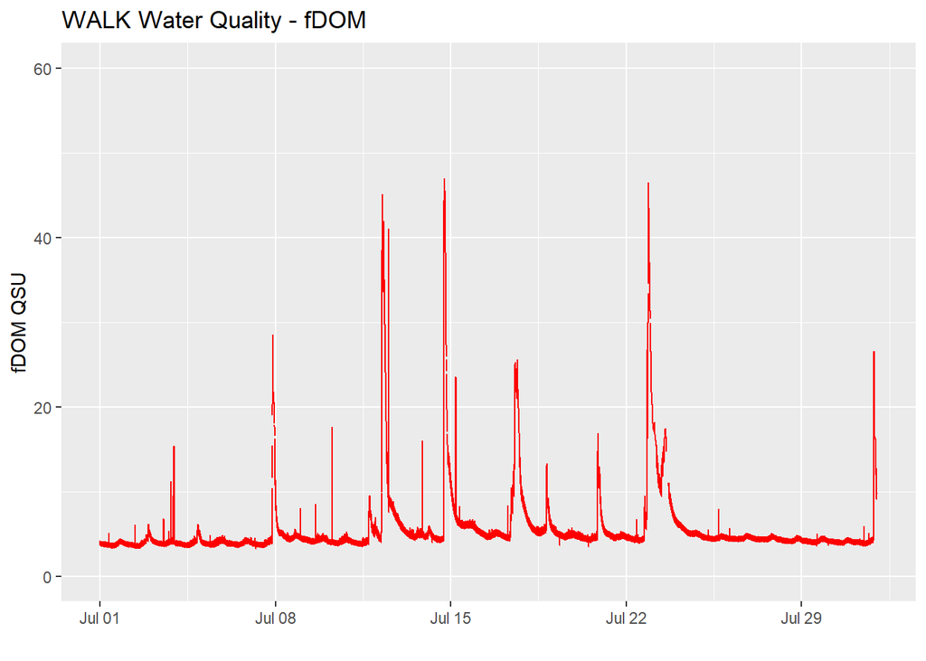

```r
# plot
plot_fDOM <- ggplot(data =waq_down,
                   aes(endDateTime, fDOM)) +
                   geom_line(na.rm=TRUE, color="red") +
                    ylim(0, 60) + ylab("fDOM QSU") + xlab(" ") +
                   ggtitle("WALK Water Quality - fDOM")

plot_fDOM
```

### Challenge: Plot Nitrate in Surface Water Data

Using what you’ve learned above, identify column names for nitrate in surface water (DP1.20033.001) and continuous discharge (DP4.00130.001)

```r
print("Nitrate in surface water column names:")
# what is the column name of the data stream of interest?
names(NSW_15_minute)

print("Continuous discharge column names:")
# what is the column name of the data stream of interest?
names(csd_continuousDischarge)
```

Using what you’ve learned above, plot nitrate in surface water.

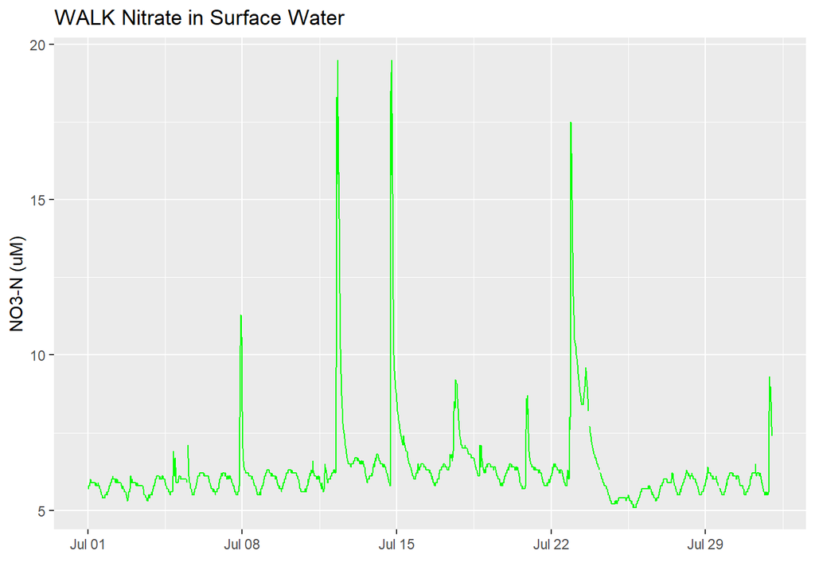

```r
# plot
plot_NSW <- ggplot(data = NSW_15_minute,
                   aes(endDateTime, surfWaterNitrateMean)) +
                   geom_line(na.rm=TRUE, color="green") +
                   ylab("NO3-N (uM)") + xlab(" ") +
                   ggtitle("WALK Nitrate in Surface Water")

plot_NSW
```

Note most NEON data products are published with uncertainty values. Continuous discharge uses a Bayesian Model, with uncertainty in the model priors (parametric uncertainty) and additional uncertainty from how well the posterior model fits the observations (remnant uncertainty). Lets try adding the remnant uncertainty to the continuous discharge plot.

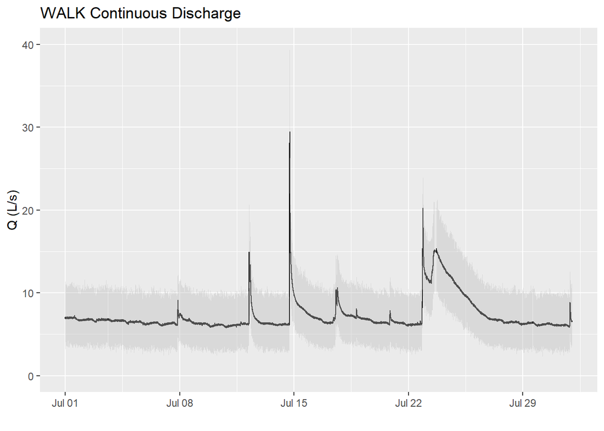

```r
# plot
plot_Q <- ggplot() +
    geom_line(data = csd_continuousDischarge,
              aes(endDate, maxpostDischarge),
              na.rm=TRUE, color="black") +
  geom_ribbon(data=csd_continuousDischarge,
              aes(x=endDate,
                  ymin = (withRemnUncQLower1Std),
                  ymax = (withRemnUncQUpper1Std)),
              alpha = 0.4, fill = "grey75") +
    geom_line( na.rm = TRUE) +
    ylim(0, 40) + ylab("Q (L/s)") +
    xlab(" ") +
  ggtitle("WALK Continuous Discharge")

plot_Q
```